# SedReview GUI v1.0 User Guide

February 13, 2019

## Introduction

SedReview has two main modules that are accessed by clicking on either Module tab at the top of the screen:  
**Site-Level Assessment Module**  
— Intended for use by project managers or other project staff to review and plot sediment data from a specific site.  
**Science-Center Review Module**  
— Intended for use by office managers, specialists, or external reviewers who wish to perform high-level reviews of data from an entire Water Science Center.

Throughout all tables in SedReview:

- You can sort the table by clicking on any of the column headers.
- You can select which columns are displayed in table by clicking on the Column Visibility button and selecting/de-selecting the headers.
- You can download the table in .csv, Excel, or .pdf format by clicking on the Download button. NOTE: .pdf downloads for large datasets may be slow or cause the program to crash. File downloads in .csv or Excel format may be a better choice than .pdf for large datasets.
- You can search for a particular entry, parameter code, etc. by typing in the text or number of interest in the “Search” box at the upper right of the table.

Additionally, you can right click your mouse outside of the plots or user inputs on any screen, and select Save As an html file to preserve the last state of the SedReview session. Only tabs, tables, and plots that were populated as part of the session will be preserved.

## Before Running SedReview: Setting up ODBC Connection to NWIS

This can be done without admin privileges, but your database administrator or IT specialist may need to assist with these steps.

**Step 1**  
You need to setup a user Data Source Name (User DSN).  
On 64bit Windows 7 and 8, run “C:/Windows/SysWOW64/odbcad32.exe”.  
On 32bit Windows 7 and 8, run “C:/Windows/System32/odbcad32.exe”.  
On 64bit Windows 10, in a Windows explorer window, paste “Control Panel/All Control Panel Items/Administrative Tools” and select “ODBC Data Sources (32-bit).”

In the User DSN tab, if you do not see a connection with the same name as your NWIS server of interest, you must add a new connection. Click “Add” on the right.

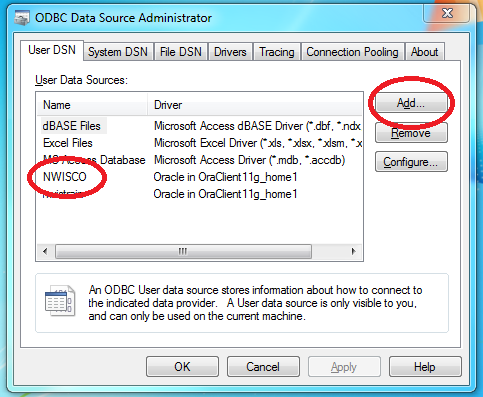

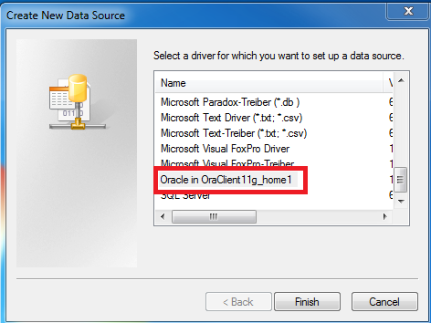

**Step 3**  
A new dialogue will appear. Click the dropdown box next to “TNS Service Name” and select the NWIS server you would like to connect to. After selecting the server, type in the server name into the “Data Source Name” text box at the top. *DO NOT ENTER A USER ID, LEAVE THIS FIELD BLANK.* You are finished, click OK to close the dialogue and then click OK in the main ODBC Data Source Administrator application to close the application.

[figure not shown]

## Installing and Opening SedReview

**Prior to installation it is recommended that you set your default browser to Google Chrome or MS Edge. SedReview has not been tested on other browsers**

1. Download the install file from [USGS ScienceBase](https://www.sciencebase.gov/catalog/item/5c867842e4b09388244b3cb3) and double click to install the program. You should not need administrator privileges to install the file.
2. Save the program where desired (e.g. user/Documents/SedReview or C:/ drive). It is recommended that you choose the options to also install a desktop shortcut and start menu folder for launching the program.
3. When installed, double click the desktop icon, navigate to the SedReview start menu folder, or navigate to the location where installed and double click the “runSedReviewGUI.bat” file.
4. The program will open a Windows console (do not close this when working in SedReview!) and then will launch SedReview in an internet browser window. You can resize the GUI within the browser window using the CTRL + or CTRL - .
5. Navigate between the two modules by clicking the desired module tab at the top of the screen, and then navigating between tabs (located below the Module informational header near the top of the screen). Tabs are activated by clicking on the blue text heading or drop-down menu icon.

## Site-Level Assessment Module

#### User Input and Summary Tab

1. Enter the following information in the fields on the left of the screen:
   - ODBC database connection name (e.g., NWISCO, NWISID, etc)
   - Database number for environmental samples
   - Database number for QA samples
   - USGS station ID for the station you want to review (8- or 15-digit)
   - Starting date for reference period. A reference period is a historical period with data that you may want to include on plots and in selected tables, for comparison with data during your main period of interest (analysis period). If you do not wish to include any historical/reference data, select the same starting dates for reference and analysis periods.
   - Starting date for analysis period. This is the start date for the period with data you want to review for your site.
   - Ending date for reference and analysis periods. This is the last date of the period with data you want to review for your site.
   - Local time zone for site being reviewed.
   - Use the buttons at the top of this box to 1) Load previously saved database info, 2) Load current session database info that was entered into the Science-Center Review module, or 3) Save the input database info to use again in a future session.
2. Once these fields are populated, click the Get data! button at the bottom.
3. A table of summary statistics is populated on the right of the screen.
4. Column header definitions:
   - SITE_NO = USGS station ID
   - STATION_NM = USGS station name
   - PARM_CD = NWIS parameter code (see https://nwis.waterdata.usgs.gov/nwis/pmcodes/)
   - PARM_NM = NWIS parameter name (see website listed above for parameter codes)
   - WY = Water year (October — September)
   - xsection = denotes whether a sample is a full cross-sectionally integrated sample (e.g. an EDI or EWI sample would be marked as a X-Section sample; a grab sample or autosample would be marked as a Pt/non-X-section sample). This is used to group and compare samples by type (so their summary statistics are kept separate) and for box coefficient calculations in a later routine.
   - n = number of samples
   - min = minimum value for data summarized
   - max = maximum value for data summarized
   - median = median value for data summarized
   - mean = mean or average value for data summarized
   - stdev = standard deviation for the data summarized
   - non_detects = number of samples coded as not detected or below the method detection limit
   - no_result_reported = number of samples that have no laboratory analytical result.

#### Rejected Sediment Data

1. Click on the Rejected Sediment Data tab. The table in this tab displays samples that are coded as Q (reviewed and rejected) or X (proprietary, reviewed and rejected) as a quick check on data quality problems and patterns for sample rejection.
2. Column header definitions (see current NWIS documentation for full descriptions and possible codes at http://nwis.usgs.gov/currentdocs/index.html):
   - RECORD_NO = NWIS unique record number for the sample
   - STATION_NM = USGS station name
   - SAMPLE_START_DT = Start date identified for the sample
   - PROJECT_CD = Project ID entered in NWIS
   - PARM_CD = NWIS parameter code (see https://nwis.waterdata.usgs.gov/nwis/pmcodes/)
   - PARM_NM = NWIS parameter name (see website listed above for parameter codes)
   - RESULT_VA = Analytical result for the sample
   - REMARK_CD = Result-level remark codes (such as <, less than; >, greater than; E, estimated).
   - VAL_QUAL_CD = Value qualifier codes
   - DQI_CD = Data Quality Indicator Code (in this table, possible values shown are A, historical data; S, provisional; I, awaiting review; R, reviewed and approved; Q, reviewed and rejected; P, proprietary and not reviewed; O, proprietary, reviewed and approved; X, proprietary, reviewed and rejected; and U, research or unapproved method or laboratory)
   - RESULT_MN = Name of the user account that was the source of the last modification to the sample record
   - PREP_DT = Sample preparation date at laboratory
   - ANL_DT = Sample analysis date at laboratory
   - LAB_NO = Laboratory ID
   - PREP_SET_NO = Analytical preparation set number at laboratory
   - ANL_SET_NO = Analytical set number at laboratory
   - ANL_ENT_CD = Analytical entity (laboratory) code
   - RPT_LEV_CD = Report level type code
   - Val_qual = Value qualifier code
   - AGENCY_CD = Agency ID
   - ANL_STAT_CD = Analysis status code
   - HYD_COND_CD = Hydrologic condition code
   - SAMP_TYPE_CD = Sample type code
   - HYD_EVENT_CD = Hydrologic event code
   - COLL_ENT_CD = Collecting entity ID

#### Outlier Explorer

1. Click on the Outlier Explorer tab. This tab will allow the user to view potential outliers in a dataset based on percentiles.
2. All data retrieved in the User Input and Summary will be shown as light gray dots in the plots on the right. Modify what is plotted by selecting different parameters in the dropdown menus on the left side of the screen.
3. Select different percentiles for defining what may be an outlier in the dataset. Currently different percentiles can be defined for 1) ’high" or “greater than” outliers (percentiles 0.80 to 0.99) and 2) “low” or “less than” outliers (percentiles 0.01 to 0.20). Any samples with values above the “greater than” percentile and below the “less than”" percentile will be shown as black dots in the plots on the right.
4. Click the box next to “Add label to plot” below the dropdown menus on left to display the record number next to any outliers shown on the plots. Labels are record#_database#.
5. Individual sample results (all samples, not just outliers) are displayed in the table under the plots.

#### Data Flags and Summary

1. Click on the Data Flags and Summary tab. A number of different summaries and data quality checks are available through this tab.
2. The Data Flag Summary table displays any sample **DURING THE ANALYSIS PERIOD** that had a “flag” for one of the data quality checks. The data quality checks are described at the top of the table and repeated here:
   - bagIEFlags: Tests whether required intake efficiency test parameters are reported when bag samplers are used (required as of June 2013 per OSW Memo 2013.03). Flags if missing.
   - CommentNoResultFlags: Returns a table with sample or analytical result comments and tests whether an analytical result is missing for a sample.
   - Qflags: Tests whether some measure of discharge is provided as metadata for a sample. Flags if missing.
   - metaDataFlags: Tests whether samples are missing required sample metadata, such as sample purpose, sampler type, sampling method, and type of associated QA with sample (if applicable). Includes tests in NWIS 20.xx level checks. For more information, see: link to NWIS 20.xx level checks available on the tab: “Data Flags and Summary > Metadata check” in the dropdown menu.
   - samplePurpFlags: Tests whether a sample purpose code (71999) differs from other samples collected at site (there are certainly valid reasons for this, but just provides a reminder to check that these are correct.
   - samplerTypeFlags: Tests whether a sampler type code (84164) differs from others reported. Flags if sampler type code is used 3 or fewer times (again, there are valid reasons for this, so just a check).
   - sedMassFlags: Tests whether a sample has a sediment mass less than 2 milligrams. Flags if so. (Note: this is a new piece of metadata (pcode 91157) reported by USGS sediment laboratories so will not be available for historical data).
   - tssFlags: Tests whether there is a Total-Suspended Solids (TSS) result without an accompanying suspended-sediment concentration (SSC) result, per OSW memo 01.03. Flags if TSS stands alone.
   - verticalsFlags: Tests whether sufficient verticals were sampled and reported (criteria are between 4 and 9 verticals for an EDI sample and between 10 and 20 verticals for an EWI samples).
   - qaqcFlags: Tests whether samples coded as SSC, bedload, or bedload mass are stored in the QA database. Flags if a sediment sample is in the QA database. This is a check to see if any sediment samples have been entered (manually or otherwise) into the QA database.
3. The results in the other tabs under the Data Flag Summary, which are described below, include samples from **BOTH THE REFERENCE (HISTORICAL) AND ANALYSIS PERIODS**, so the sample counts in these individual tabs may differ from what is shown in the Data Flag Summary tab.
   - Sampling Method Summary — table of sample counts (by WY) of sampling method, sampler type, and bedload method (if applicable). Possible parameter codes are defined at the top of the table or provided through a link to additional sampling codes, following the header.
   - Bag Sampler IE Check — table of samples that were flagged as missing intake efficiency test parameters when a bag sampler was used (required as of June 2013 per OSW Memo 2013.03).
   - Sample/Result Comments & Missing Result Check — table of samples that had sample or analytical result comments and/or were missing laboratory analytical results. Sample and result comments are reported to identify a possible cause for missing analytical results.
   - Streamflow Check — table of samples that were missing discharge metadata.
   - Metadata Check — table of samples that were missing required sample metadata, such as sample purpose, sampler type, sampling method, and type of associated QA with sample (if applicable). Includes tests in NWIS 20.xx level checks.
   - Sample Purpose Check — table of samples with a sample purpose code that differs from the code most commonly used at a site. There are certainly valid reasons for this, but this table just serves as a reminder to check that sample purposes are generally correct.
   - Sampler Type Check — table of samples with a sampler type code that differs from the code most commonly used at a site. Flags if sampler is used 3 or fewer times. There are certainly valid reasons for this, but this table just serves as a check for possible typos during metadata entry.
   - Sediment Mass Check — table of samples with **sediment mass less than 2 milligrams**. Sediment mass is a new piece of data (**pcode 91157**) reported by USGS sediment laboratories, see **WMA Tech Note 41** for more information. Understanding of sediment mass in samples will inform project chiefs regarding uncertainties in analytical results associated with limited sample mass and may help determine whether more sample volume is needed in the future to reduce those uncertainties. A flag threshold of 2 milligrams is currently used in this table. Project chiefs should discuss mass results with their laboratory chief.
   - Unpaired-TSS Samples — table of samples that have a result for TSS but do not have a corresponding sample result for SSC. SSC analysis is required for all samples analyzed for TSS, per OSW memo 01.03.
   - EWI/EDI Verticals Check — table of EDI and EWI samples that were collected with a number of verticals outside the recommendations in Edwards and Glysson (1998), which state between 4 and 9 verticals for an EDI sample and between 10 and 20 verticals for an EWI sample). There could be valid reasons for deviation (such as for sampling in small streams).
   - DQI Status Summary — summary table of samples organized by parameter code and water year, with the corresponding number of samples with data quality indicator codes of A, historical data; S, provisional; I, awaiting review; R, reviewed and approved; Q, reviewed and rejected; P, proprietary and not reviewed; O, proprietary, reviewed and approved; X, proprietary, reviewed and rejected; and U, research or unapproved method or laboratory. This is helpful for determining how many samples are awaiting review and approval or rejection. DQI codes not present in a dataset will not be shown in the table.
   - QAQC Check — table of samples that were coded as suspended-sediment concentration (SSC), bedload, or bedload mass but were stored in the QA database. Note: most QA/QC samples for sediment are NOT stored in the QA database because they are considered environmental samples. Storage of sediment replicates is coded by default in SedLOGIN in the main environmental database. This is a check to see if any sediment samples have been entered (manually or otherwise) into the QA database. There may be a valid reason for storing a sediment sample in the QA database.

#### Plots

1. Click on the Plots tab drop-down menu to view time series plots, scatter plots, and box plots. Note: if data are not available to populate a specific plot, the plot will be blank, or an error message will be displayed stating “no data”.
2. The time series plots display SSC, sand/silt break (% smaller than 0.0625 mm), suspended sediment load (SSL), bedload, bedload mass, and TSS (if available) by date.
3. The scatter plots display SSC, sand/silt break, and bedload by discharge; SSC by turbidity, TSS by discharge, and TSS by SSC (if available)
4. The box plots display standard USGS box plots of: TSS and SSC (side by side for comparison of data distributions), SSC alone, and TSS alone (if available).

#### Box Coeff Explorer

1. Click on the Box Coeff Explorer tab. This tab allows further exploration of box coefficients where non-cross section and cross section sample pairs are available for assessing the representativeness of point/grab/autosampler sample locations.
2. The plot on upper right is static and displays a scatter plot of the non-cross section SSC (X axis) versus the cross-section SSC (Y axis). Sample pairs are shown as red dots. The best-fit (regression) line of all sample pairs is shown as a red line. The corresponding 95th confidence intervals (shown as gray shading) also are shown on the plot based on available sample pairs in the selected analysis period. Samples collected during the reference (historical) period and any removed samples from the analysis period are shown as black dots. The 1:1 line (box coefficient of 1) can also be plotted on the upper plot by clicking the circle next to 1:1 radio button below the dropdown menus on left.
3. The plot on lower right is customizable. Variables to plot on the X and Y axes can be selected in the dropdown menus at left. In particular, it may be useful to plot box coefficients by sample date and streamflow to see whether box coefficients are consistent or vary over seasons or streamflow.

## Science-Center Review Module

#### Reviewer Input and Summary

1. Enter the following information in the fields on the left of the screen:
   - ODBC database connection name (e.g., NWISCO, NWISID, etc)
   - Database number for environmental samples
   - Database number for QA samples
   - Two-letter state code (e.g., CO, ID, etc)
   - Starting date for the period of review (YYYY/MM/DD)
   - Ending date for the period of review (YYYY/MM/DD). The review period most likely will correspond with one or more water years, but any dates can be selected.
   - Use the buttons at the top of this box to 1) Load previously saved database info, 2) Load current session database info that was entered into the Site-Level Assessment module, or 3) Save the input database info to use again in a future session.
2. Once these fields are populated, click “Review data!”.
3. A table that summarizes the number of samples analyzed for SSC, sand/silt break (% smaller than 0.0625 mm), TSS, and bedload for each site in the database will be generated for the review period. If multiple water years exist within the review period, the results are organized by water year.

#### Map of Active Sediment Sites

1. Click on this tab to display active sediment sites in the area (state, WSC) being reviewed.
2. Select the parameter of interest from the dropdown menu on the left.
3. Click Map sites!
4. Active sediment sites with selected parameter data are shown as orange dots on the map on the right. If no data are available for the selected parameter, the map will be blank.
5. Zoom in/out on the map using the + and — buttons in the upper left corner of the map (the mouse scroll wheel can also be used).
6. The table below the map displays the sample counts analyzed for SSC, sand/silt break, TSS, and bedload by site and water year (a repeat of the table shown on the Reviewer Input and Summary tab).

#### Data Flags and Summary

1. Click on the Data Flags and Summary tab. A number of different summaries and data quality checks are available through this tab drop-down.
   - Bag sampler IE check — table of sample counts by site that were flagged as missing intake efficiency test parameters when a bag sampler was used (required as of June 2013 per OSW Memo 2013.03).
   - Streamflow check — table of sample counts by site that were missing discharge metadata.
   - QAQC check — table of sample counts by site that were coded as suspended-sediment concentration (SSC), bedload, or bedload mass but were stored in the QA database. Note: most QA/QC samples for sediment are NOT stored in the QA database because they are considered environmental samples. Storage of sediment replicates is coded by default in SedLOGIN in the main environmental database. This is just a check to see if any sediment samples have been entered (manually or otherwise) into the QA database. There may be a valid reason for storing a sediment sample in the QA database.
   - Sediment mass check — table of sample counts by site with sediment mass less than 2 milligrams. Sediment mass is a new piece of data (pcode 91157) reported by USGS sediment laboratories. Understanding of sediment mass in samples will inform managers and project chiefs regarding uncertainties in analytical results associated with limited sample mass and may help determine whether more sample volume is needed in the future to reduce those uncertainties. A flag threshold of 2 milligrams is currently used in this table. Managers and project chiefs should discuss mass results with their laboratory chief.
   - Unpaired-TSS sample check — table of sample counts by site that have a result for TSS but do not have a corresponding sample result for SSC. SSC analysis is required for all samples analyzed for TSS, per OSW memo 01.03.
   - EWI/EDI verticals check — table of EDI and EWI sample counts by site that were either missing the metadata for number of verticals or were collected with a number of verticals outside the recommendations in Edwards and Glysson (1998), which state between 4 and 9 verticals for an EDI sample and between 10 and 20 verticals for an EWI sample). There could be valid reasons for deviation (such as for sampling in small streams).
   - Sampling method summary — table of sample counts by site and water year of sampling method, sampler type, and bedload method (if applicable). Possible parameter codes are defined at the top of the table.
   - DQI status summary — summary table of sample counts by site organized by parameter code and water year, with the corresponding number of samples with data quality indicator codes of A, historical data; S, provisional; I, awaiting review; R, reviewed and approved; Q, reviewed and rejected; P, proprietary and not reviewed; O, proprietary, reviewed and approved; X, proprietary, reviewed and rejected; and U, research or unapproved method or laboratory. This is helpful for determining how many samples are awaiting review and approval or rejection. DQI codes not present in a dataset will not be shown in the table.

#### Summary Box Coeff

1. Click the Summary of Box Coef tab to view a table of non-cross section (point/grab/autosample) sample and comparison cross section (EDI/EWI) sample pairs. The information displayed can be used to assess whether WSC personnel are collecting the data needed to determine the representativeness of a point/grab/autosample sample location.
2. Enter the search interval in hours in the field on the left. The search interval is the greatest time difference considered when pairing between the point/grab/autosample sample time and the comparison cross section (EDI/EWI) sample time. If a search interval is entered that is too short for what is typical at the site, no sample pair results will be returned. You may want to start with a wide search interval (e.g. 3 hrs) at first, then narrow down as needed.
3. Click Pull Summary! The data table, organized by site and WY, will be populated below the search interval box. Note that all sites’ results are presented here, even if no non-cross section samples were collected. Look for sites that have non-cross section samples with no corresponding cross section samples and “0” for number of pairs (numPairs), which could indicate that steps are not being taken to assess the representativeness of point/grab/autosample sample locations.

Again, you can right click your mouse outside of the plots or user inputs on any screen, and select Save As an html file to preserve the last state of the SedReview session. Only tabs, tables, and plots that were populated as part of the session will be preserved.

## Known Issues

| Number | Module (Site Level Assessment (SLA) / Science Center Review (SCR)) | Issue | Status |
| --- | --- | --- | --- |
| 1 | SCR and SLA | A message stating “<h2></h2>”" appears in PDF outputs of tables |  |
| 2 | SCR | A pop up “ghost” appears in the Map Sites by PCode Tab | Currently out of our control; it can be removed by going back to the screen it originally appeared in, and hovering over it again and then moving out of the box back towards the input value. |
| 3 | SLA | Points on box coefficient plots are not clickable or selectable | Can drag a box around the points to see information in the table below; additional functionality will come later. |
| 4 | SLA | Some samples are repeated in the table below graph in the box coeff data pull routine |  |
| 5 | SCR and SLA | Some data retrievals (particularly several WYs) take a long time to perform | This may continue to be a problem depending on connection speed. Try limited data retrievals to shorter time periods if this occurs. |

Also see: [SedReview GitHub Issues Page](https://github.com/USGS-R/sedReview/issues)

## Planned Enhancements (FY19 and beyond)

1. Entries for ODBC database, database numbers to carry over between the Site-Level Assessment and Science-Center Review Modules; also to be autosaved for subsequent uses.
2. More functionality for clicking on points in plots and displaying information. Also ability to select/deselect individual samples to plot.
3. Ability to produce qwbatch files to change DQI codes or to insert missing metadata en masse (functionality may have to wait until conversion from QWDATA to AQ SAMPLES).
4. More functionality on outlier plots; incorporation of other ways of identifying a point as an outlier.
5. Incorporate a mergeQ routine (which has been developed but is not fully functional) which retrieves the nearest instantaneous discharge value to the sample time and allows calculation of loads for plots. Want to allow user to batch load the matched discharge value for all samples missing this metadata.
6. Overall error trapping and improvement in feedback to user when data are not available or are potentially erroneous.
7. Allow log scales on some plots.
8. Improvements overall on plots: plot scaling, zooming, inclusion of other parameters, etc.
9. Include a 1:1 line on the Box Coeff Data Pull tab plot.
10. Improved data retrieval speeds, where possible.
11. Include a flag when sediment mass is less than 20 mg, possibly 10 mg.
12. Include plots of sample grain size distribution and calculation of metrics such as D20, D50, D80, etc.
13. Include checks on transit rates, where data are available.
14. Include comparisons between A and B passes (sediment replicates).
15. Include more checks on mandatory metadata, particularly for bedload samples.

#### Any Questions or Enhancement Requests?

Contact the SedReview development team: GS-W SedReview Help (gs-w_sedreview_help@usgs.gov)  
or  
Submit an Issue on the [SedReview GitHub Issues Page](https://github.com/USGS-R/sedReview/issues)